# *Exploring the effect of age on number of visits to the doctor

3/03/25

**Abstract**

People often associate old age with a series of health conditions and diseases but does old age necessarily correlate with the number of hospital visits and are there other predictors for the number of yearly hospital visits? We attempted to answer this by regressing the number of hospital visits on age and multiple other variables. Our research determined that being old and having more children negatively impacted the number of visits. Having health conditions and being enrolled in the supplemental security income program positively impacted hospital visits. Additionally other factors like gender and income did not appear to impact visits.

## Descriptive Statistics

```
Descriptive Statistics
=================================================
Statistic  N   Mean   Median St. Dev.  Min   Max
-------------------------------------------------
visits    996  1.93     1      3.35     0    50
age       996  55.21    66    24.96    16    105
health1   996 -0.0000 -0.32    1.44   -2.26 7.22
access    996  0.40    0.42    0.18   0.00  1.00
income    996  8.19    7.99    3.63   0.50  17.50
-------------------------------------------------
```

```
Descriptive Statistics
=============================================
Statistic     N  Mean Median St. Dev. Min Max
---------------------------------------------
children     996 1.31   1      1.51    0   9
gender       996 0.85   1      0.36    0   1
program type 996 0.51   1      0.50    0   1
---------------------------------------------
```

*From the above tables we can infer the following:*

**For Visits:**

- The mean number of visits is 1.93, while the median is 1, indicating that the distribution is right-skewed (some individuals have significantly more visits).
- The standard deviation is 3.35, showing a relatively high variation in the number of visits.
- The minimum value is 0, and the maximum is 50, suggesting that some individuals do not visit at all, while others have frequent visits.

**For Age:**

- The mean age is 55.21 years, and the median is 66 years, suggesting a left-skewed distribution.
- The standard deviation is 24.96, indicating a broad variation in ages.
- The minimum age is 16 years, and the maximum is 105 years, highlighting a diverse age range.

**For Income:**

- The mean income is 8.19, while the median is 7.99, showing a nearly symmetric distribution.
- The standard deviation is 3.63, indicating moderate variation in income.
- The minimum value is 0.50, and the maximum is 17.50, suggesting a wide income range.

**For Health1:**

- The mean health score is approximately 0, and the median is -0.32, indicating a balanced distribution around zero.
- The standard deviation is 1.44, reflecting moderate variability in health scores.
- The minimum value is -2.26, while the maximum is 7.22, showing a broad range of health levels.

**For Access:**

- The mean access score is 0.40, and the median is 0.42, showing that the data is almost symmetrically distributed.
- The standard deviation is 0.18, indicating low variability.
- The minimum value is 0.00, and the maximum is 1.00, suggesting a binary or percentage-based scale.

**For Children:**

- The mean number of children is 1.31, while the median is 1, indicating that most individuals have one child.
- The standard deviation is 1.51, suggesting considerable variation in the number of children.
- The minimum value is 0, and the maximum is likely higher, indicating that some individuals have no children while others have multiple.

**For Gender:**

- The mean value for the binary variable female is 0.85, meaning that 85% of the individuals in the dataset are female.
- The median is 1, which aligns with the fact that the majority of the dataset consists of females.

**For Program:**

- The mean value for ssi is 0.51, indicating that 51% of individuals in the dataset are part of the Supplementary Security Income (SSI) program.
- This suggests that the data is equally distributed, with half of the sample population belonging in each category.

## Graphs

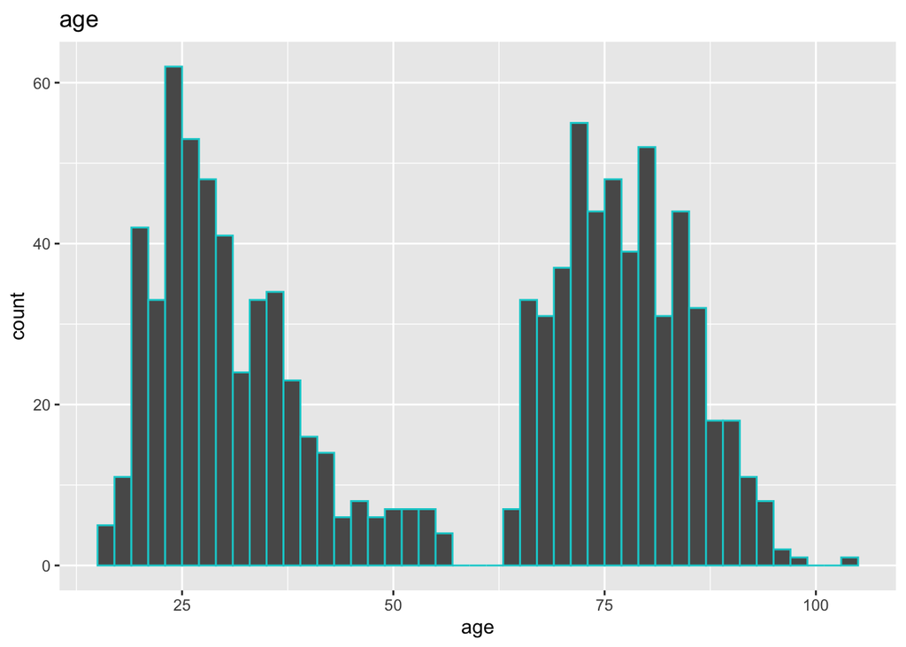

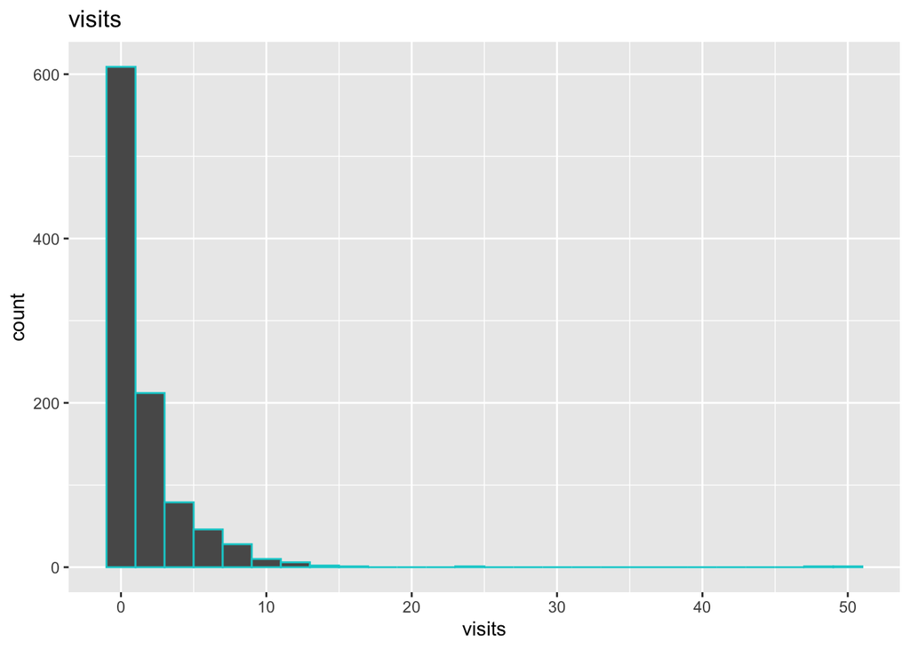

**Based on the Age bar plot, we can infer the following:** - The bar plot for age has two distinct peaks that show that most people who responded to the survey lie between 20 to 34 years old and 65 to 90 years old. This means that there is a lack of middle aged people within the surveyed population.

**Based on the Visits bar plot, we can infer the following:** - The bar plot shows that the mode is 0 visits with the number of visits consistently decreasing until 5 visits. After 5 visits, the number of people who visited more times fluctuates with outliers at 24, 48, and 50 visits.

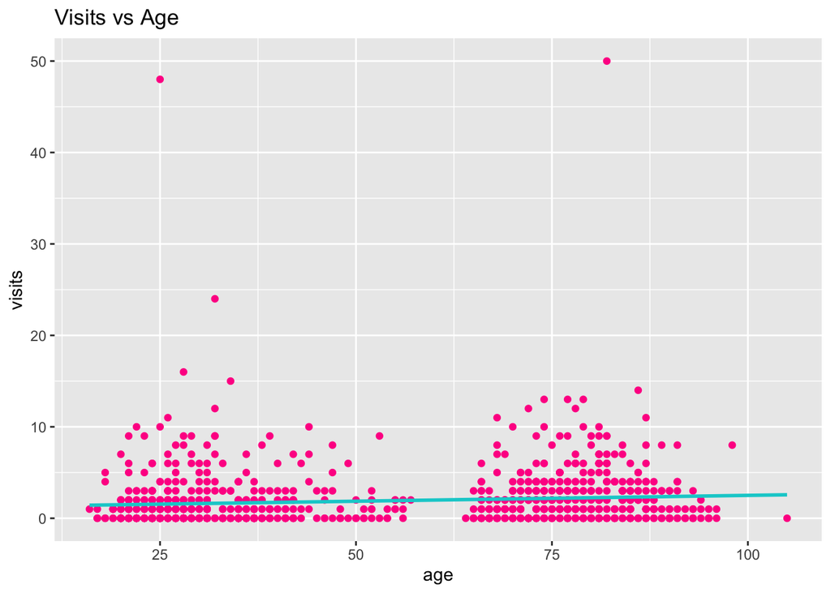

**Based on the Visits vs. Age scatter plot, we can infer the following:**

- The regression line suggests a slight upward trend, indicating a weak positive correlation between age and the number of hospital visits. As individuals get older, they may be slightly more likely to visit the hospital.
- The slope is almost flat, suggesting that age alone does not strongly predict hospital visits.
- There are several outliers, with a few individuals having more than 20 hospital visits, and even a case where the number of visits reaches 50. These extreme values might be influencing the regression trend.
- Most data points are clustered near 0 visits, across all age groups, suggesting that many individuals do not frequently visit hospitals.
- The distribution of hospital visits appears to be scattered across different age groups, without a clear trend. Other factors such as health conditions, income, or healthcare access might play a more significant role in determining hospital visit frequency.